Kadir İnip 29.01.2021 HW4 - Forecasting with ARIMA

## Introduction

Electric consumption is a critical tool for all industries as the data come from consumption gives us predictions about the future price and future demand. In this project, I will forecast the next 14 days “Electricity Consumption” daily basis for using only the last 4 years consumption data which come from EPIAS that is the data center for public-purposes to transparency situations in electricity production market in Turkey.

In essence, there are a lot of regressors which affects the electricity consumption in Turkey, special and religious days, holidays, weather temperature, industry indexes etc. Naturally, electricity consumption differs from hour to hour, weekdays to weekdays. In this work, we observe first the long-run electricity consumption plot, then Moving Average plots. After that, I will begin the forecasting parts.

## Reading and Manipulating Data

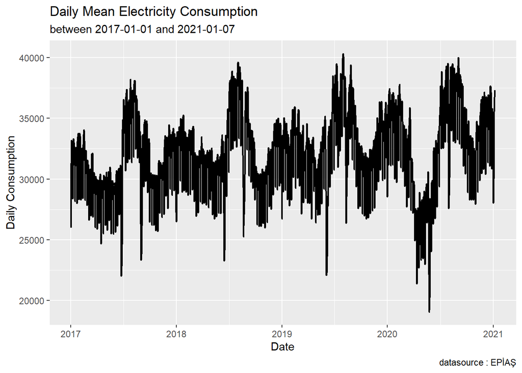

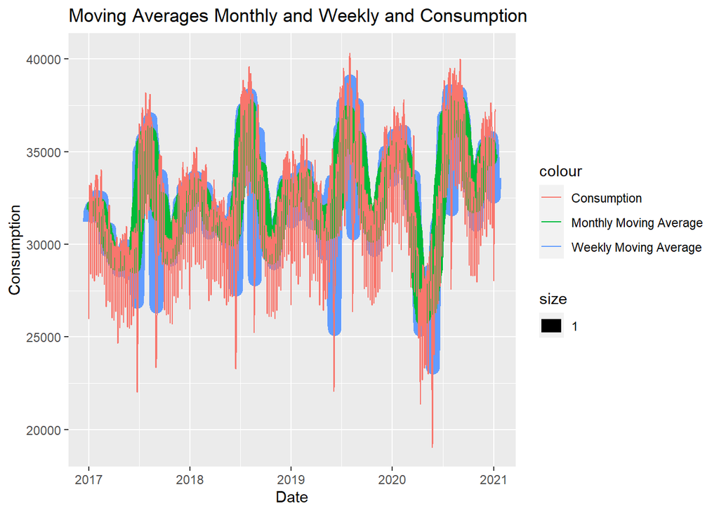

Here, too, the graph below is the graph of the graphics with 7 and 30-day moving averages. Since visualizing the data in full is not the subject of this assignment, I will not give much detail. But I want to present you a week by drawing a monthly plot chart.

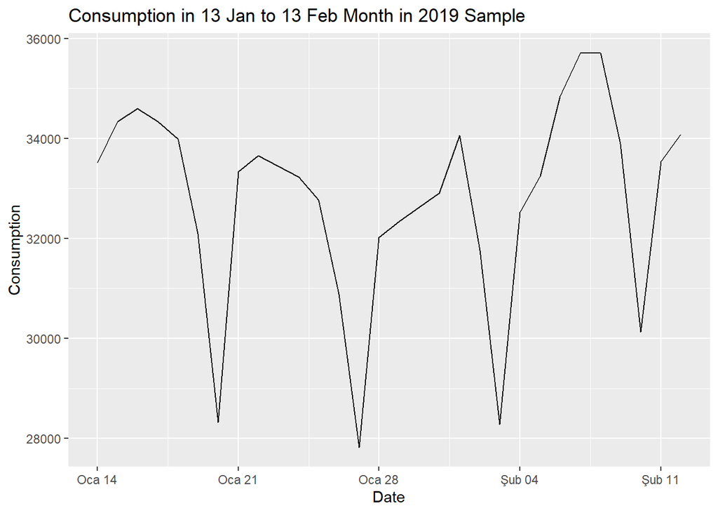

## Decomposition

First of all, we should decompose the data in order to hold stationary in the variables.

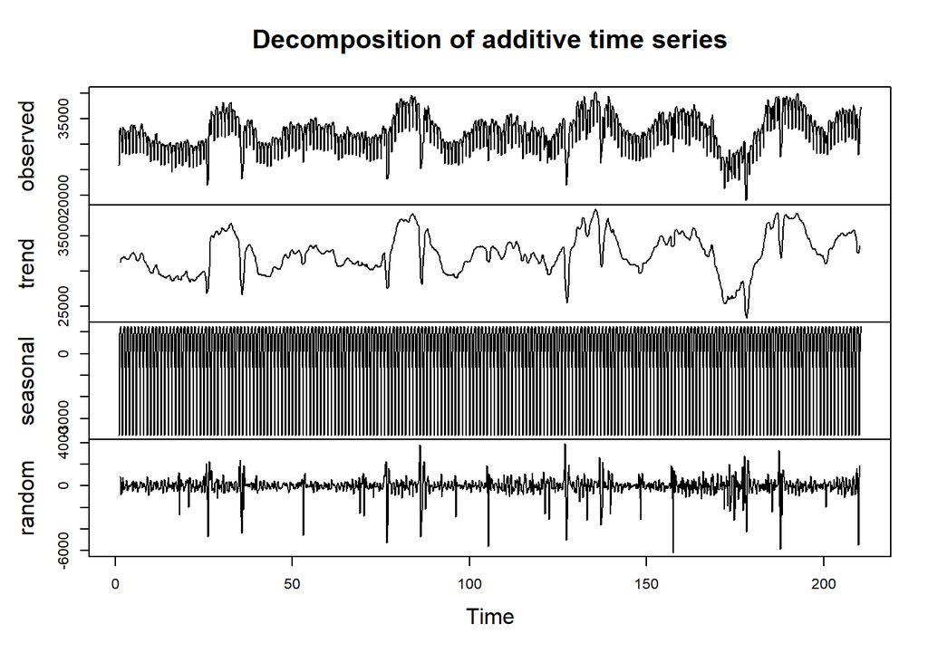

This is the decomposed part of the raw data, the seasonality is seasonal effect which was up and down strictly. Random component and trend is given that. If KPSS test is well, we will use the random component and make an arima model into random component.

```
##
## #######################
## # KPSS Unit Root Test #
## #######################
##
## Test is of type: mu with 7 lags.
##
## Value of test-statistic is: 0.0046
##
## Critical value for a significance level of:
##                 10pct  5pct 2.5pct  1pct
## critical values 0.347 0.463  0.574 0.739
```

The random component of the decomposed data is very low, it means that we can use that, as it is stationary in the 0.01 significance level also.

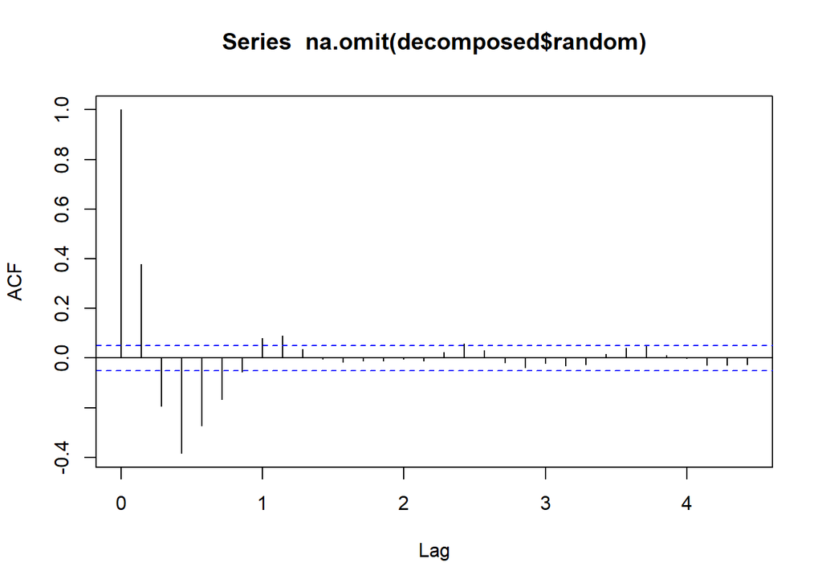

ACF plot is used to understand the behaviour of lag-k in the random component. However, the auto.arima() function gives the best model.

```
##
##  Fitting models using approximations to speed things up...
##
##  ARIMA(2,0,2)           with non-zero mean : Inf
##  ARIMA(0,0,0)           with non-zero mean : 23865.43
##  ARIMA(1,0,0)           with non-zero mean : 23640.6
##  ARIMA(0,0,1)           with non-zero mean : 23526.04
##  ARIMA(0,0,0)           with zero mean     : 23863.43
##  ARIMA(1,0,1)           with non-zero mean : 23525.08
##  ARIMA(2,0,1)           with non-zero mean : Inf
##  ARIMA(1,0,2)           with non-zero mean : 23228.89
##  ARIMA(0,0,2)           with non-zero mean : 23519.22
##  ARIMA(1,0,3)           with non-zero mean : Inf
##  ARIMA(0,0,3)           with non-zero mean : Inf
##  ARIMA(2,0,3)           with non-zero mean : Inf
##  ARIMA(1,0,2)           with zero mean     : 23227.45
##  ARIMA(0,0,2)           with zero mean     : 23517.21
##  ARIMA(1,0,1)           with zero mean     : 23523.07
##  ARIMA(2,0,2)           with zero mean     : Inf
##  ARIMA(1,0,3)           with zero mean     : Inf
##  ARIMA(0,0,1)           with zero mean     : 23524.03
##  ARIMA(0,0,3)           with zero mean     : Inf
##  ARIMA(2,0,1)           with zero mean     : Inf
##  ARIMA(2,0,3)           with zero mean     : Inf
##
##  Now re-fitting the best model(s) without approximations...
##
##  ARIMA(1,0,2)           with zero mean     : Inf
##  ARIMA(1,0,2)           with non-zero mean : Inf
##  ARIMA(0,0,2)           with zero mean     : 23517.16
##
##  Best model: ARIMA(0,0,2)           with zero mean
```

The AIC value is better in the ARIMA(0,0,2) model, however, we can reduce it by trying different models. To do that, firstly we will check the ACF plots then, then adding the extra new regressions into model to improve.

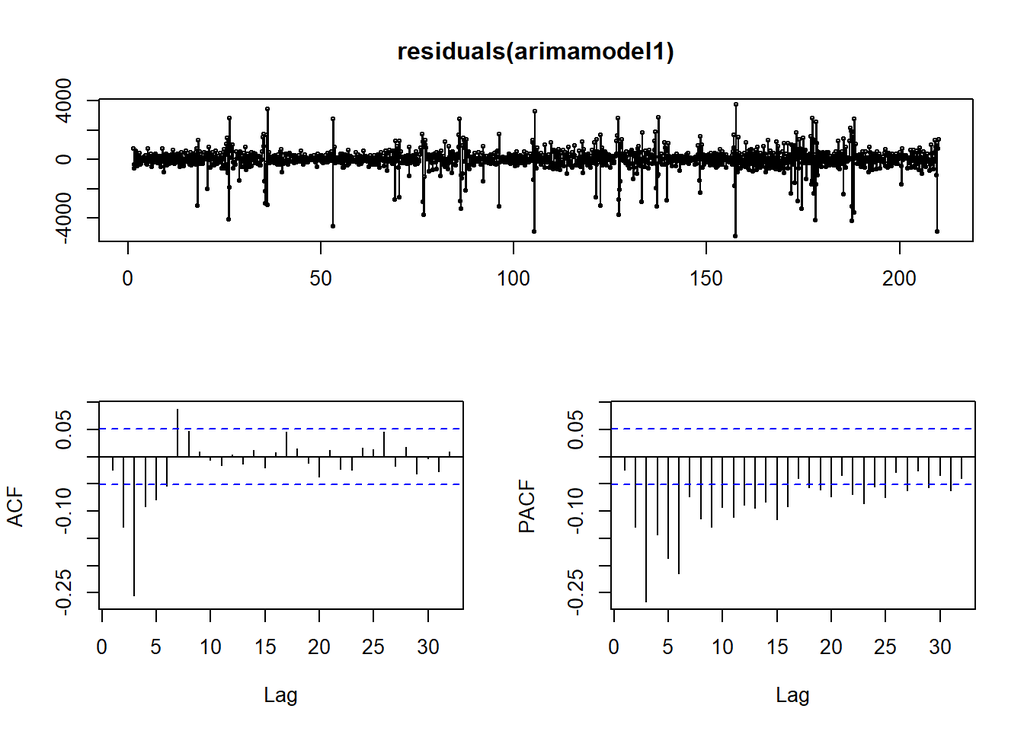

We awared that, the lag-3 is important here, so arima model should be improved via new order=c(3,0,2).

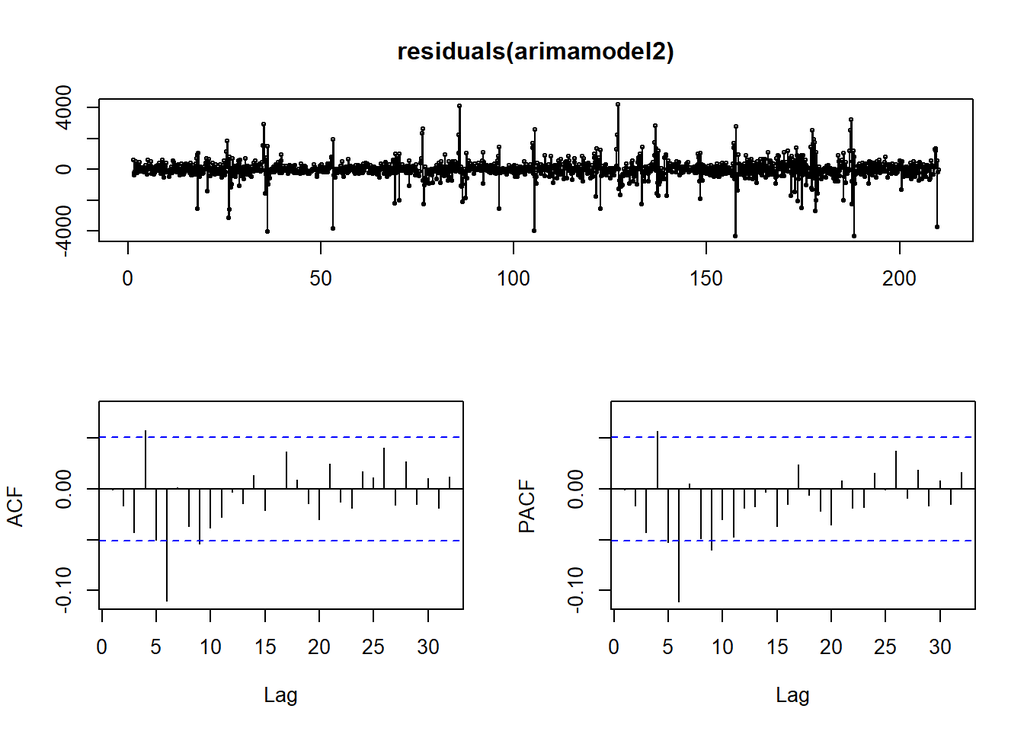

Now, the lag-6 is really high in the ACF also PACF. So we will improve the the model via order = c(6,0,2).

```
##
##  Fitting models using approximations to speed things up...
##
##  ARIMA(2,0,2)(1,0,1)[7] with non-zero mean : Inf
##  ARIMA(0,0,0)           with non-zero mean : 23865.43
##  ARIMA(1,0,0)(1,0,0)[7] with non-zero mean : 23632.99
##  ARIMA(0,0,1)(0,0,1)[7] with non-zero mean : 23518.5
##  ARIMA(0,0,0)           with zero mean     : 23863.43
##  ARIMA(0,0,1)           with non-zero mean : 23526.04
##  ARIMA(0,0,1)(1,0,1)[7] with non-zero mean : 23523.77
##  ARIMA(0,0,1)(0,0,2)[7] with non-zero mean : 23520.41
##  ARIMA(0,0,1)(1,0,0)[7] with non-zero mean : 23521.74
##  ARIMA(0,0,1)(1,0,2)[7] with non-zero mean : 23525.76
##  ARIMA(0,0,0)(0,0,1)[7] with non-zero mean : 23857.49
##  ARIMA(1,0,1)(0,0,1)[7] with non-zero mean : 23516.73
##  ARIMA(1,0,1)           with non-zero mean : 23525.08
##  ARIMA(1,0,1)(1,0,1)[7] with non-zero mean : 23523.06
##  ARIMA(1,0,1)(0,0,2)[7] with non-zero mean : 23518.62
##  ARIMA(1,0,1)(1,0,0)[7] with non-zero mean : 23521.1
##  ARIMA(1,0,1)(1,0,2)[7] with non-zero mean : 23525.09
##  ARIMA(1,0,0)(0,0,1)[7] with non-zero mean : 23629.14
##  ARIMA(2,0,1)(0,0,1)[7] with non-zero mean : Inf
##  ARIMA(1,0,2)(0,0,1)[7] with non-zero mean : 23228.57
##  ARIMA(1,0,2)           with non-zero mean : 23228.89
##  ARIMA(1,0,2)(1,0,1)[7] with non-zero mean : Inf
##  ARIMA(1,0,2)(0,0,2)[7] with non-zero mean : 23230.21
##  ARIMA(1,0,2)(1,0,0)[7] with non-zero mean : Inf
##  ARIMA(1,0,2)(1,0,2)[7] with non-zero mean : Inf
##  ARIMA(0,0,2)(0,0,1)[7] with non-zero mean : 23509.83
##  ARIMA(2,0,2)(0,0,1)[7] with non-zero mean : Inf
##  ARIMA(1,0,3)(0,0,1)[7] with non-zero mean : Inf
##  ARIMA(0,0,3)(0,0,1)[7] with non-zero mean : Inf
##  ARIMA(2,0,3)(0,0,1)[7] with non-zero mean : Inf
##  ARIMA(1,0,2)(0,0,1)[7] with zero mean     : 23227.13
##  ARIMA(1,0,2)           with zero mean     : 23227.45
##  ARIMA(1,0,2)(1,0,1)[7] with zero mean     : Inf
##  ARIMA(1,0,2)(0,0,2)[7] with zero mean     : 23228.77
##  ARIMA(1,0,2)(1,0,0)[7] with zero mean     : Inf
##  ARIMA(1,0,2)(1,0,2)[7] with zero mean     : Inf
##  ARIMA(0,0,2)(0,0,1)[7] with zero mean     : 23507.81
##  ARIMA(1,0,1)(0,0,1)[7] with zero mean     : 23514.71
##  ARIMA(2,0,2)(0,0,1)[7] with zero mean     : Inf
##  ARIMA(1,0,3)(0,0,1)[7] with zero mean     : Inf
##  ARIMA(0,0,1)(0,0,1)[7] with zero mean     : 23516.49
##  ARIMA(0,0,3)(0,0,1)[7] with zero mean     : Inf
##  ARIMA(2,0,1)(0,0,1)[7] with zero mean     : Inf
##  ARIMA(2,0,3)(0,0,1)[7] with zero mean     : Inf
##
##  Now re-fitting the best model(s) without approximations...
##
##  ARIMA(1,0,2)(0,0,1)[7] with zero mean     : Inf
##  ARIMA(1,0,2)           with zero mean     : Inf
##  ARIMA(1,0,2)(0,0,1)[7] with non-zero mean : Inf
##  ARIMA(1,0,2)(0,0,2)[7] with zero mean     : Inf
##  ARIMA(1,0,2)           with non-zero mean : Inf
##  ARIMA(1,0,2)(0,0,2)[7] with non-zero mean : Inf
##  ARIMA(0,0,2)(0,0,1)[7] with zero mean     : 23507.72
##
##  Best model: ARIMA(0,0,2)(0,0,1)[7] with zero mean
```

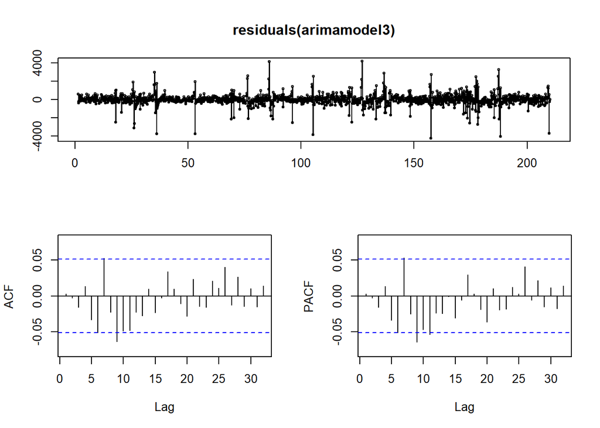

This is the summary of model.

```
##
## Call:
## arima(x = decomposed$random, order = c(6, 0, 2))
##
## Coefficients:
##          ar1     ar2      ar3     ar4      ar5      ar6      ma1      ma2
##       0.4103  0.2547  -0.4878  0.1156  -0.0483  -0.0833  -0.2042  -0.7958
## s.e.  0.4829  0.5823   0.3407  0.0421   0.0469   0.0613   0.4820   0.4820
##       intercept
##         -0.0036
## s.e.     0.0834
##
## sigma^2 estimated as 393490:  log likelihood = -11495.57,  aic = 23011.13
##
## Training set error measures:
##                    ME     RMSE      MAE      MPE     MAPE     MASE        ACF1
## Training set 1.316973 627.2882 370.5036 56.50638 219.8974 0.688677 0.003130191
```

In the section given below, we have forecast the next 14 days using the seasonal and trend variables of the last 14 days. Then we completed the report by calculating the error coefficients and WMAPE value.

```
##    n     mean       sd       bias       mape      mad     wmape
## 1 14 37045.79 2567.339 0.09519714 0.09760274 3721.531 0.1004576
```

## Conclusion

In this report, I tried to forecast the electricity consumption based on the last 4 year data in Turkey. Respectively, I read the data, manipulated and visualized, then decomposed because of the stationary assumptions. As, if the data has not stationary mean and variance, the forecast will be biased, and the model will not fit. Then, I calculate the errors by using WMAPE formula. The model which used here is ARIMA(6,0,2) which means that calculate to lag(6) and 2-order MA.

# RMD file

[Here](https://bu-ie-360.github.io/fall20-kadirnp/files/HMW4.Rmd) the RMD File including the code chunks can be found.